# RxODE Data Frames

2019-05-30

[output not shown]

```
#> ______________________________ Solved RxODE object _____________________________
#> -- Parameters ($params): -------------------------------------------------------
#>      V2      V3      KA      CL       Q     Kin    Kout    EC50
#>  40.200 297.000   0.294  18.600  10.500   1.000   1.000 200.000
#> -- Initial Conditions ($inits): ------------------------------------------------
#> depot centr  peri   eff
#>     0     0     0     1
#> -- First part of data (object): ------------------------------------------------
#> # A tibble: 241 x 7
#>    time    C2    C3  depot centr  peri   eff
#>     [h] <dbl> <dbl>  <dbl> <dbl> <dbl> <dbl>
#> 1     0   0   0     10000     0     0   1
#> 2     1  44.4 0.920  7453. 1784.  273.  1.08
#> 3     2  54.9 2.67   5554. 2206.  794.  1.18
#> 4     3  51.9 4.46   4140. 2087. 1324.  1.23
#> 5     4  44.5 5.98   3085. 1789. 1776.  1.23
#> 6     5  36.5 7.18   2299. 1467. 2132.  1.21
#> # ... with 235 more rows
```

or

```r
x <- solve(mod1,theta, ev, inits)
print(x)
```

```
#> ______________________________ Solved RxODE object _____________________________
#> -- Parameters ($params): -------------------------------------------------------
#>      V2      V3      KA      CL       Q     Kin    Kout    EC50
#>  40.200 297.000   0.294  18.600  10.500   1.000   1.000 200.000
#> -- Initial Conditions ($inits): ------------------------------------------------
#> depot centr  peri   eff
#>     0     0     0     1
#> -- First part of data (object): ------------------------------------------------
#> # A tibble: 241 x 7
#>    time    C2    C3  depot centr  peri   eff
#>     [h] <dbl> <dbl>  <dbl> <dbl> <dbl> <dbl>
#> 1     0   0   0     10000     0     0   1
#> 2     1  44.4 0.920  7453. 1784.  273.  1.08
#> 3     2  54.9 2.67   5554. 2206.  794.  1.18
#> 4     3  51.9 4.46   4140. 2087. 1324.  1.23
#> 5     4  44.5 5.98   3085. 1789. 1776.  1.23
#> 6     5  36.5 7.18   2299. 1467. 2132.  1.21
#> # ... with 235 more rows
```

Or with `mattigr`

```r
x <- mod1 %>% solve(theta, ev, inits)
print(x)
```

```
#> ______________________________ Solved RxODE object _____________________________
#> -- Parameters ($params): -------------------------------------------------------
#>      V2      V3      KA      CL       Q     Kin    Kout    EC50
#>  40.200 297.000   0.294  18.600  10.500   1.000   1.000 200.000
#> -- Initial Conditions ($inits): ------------------------------------------------
#> depot centr  peri   eff
#>     0     0     0     1
#> -- First part of data (object): ------------------------------------------------
#> # A tibble: 241 x 7
#>    time    C2    C3  depot centr  peri   eff
#>     [h] <dbl> <dbl>  <dbl> <dbl> <dbl> <dbl>
#> 1     0   0   0     10000     0     0   1
#> 2     1  44.4 0.920  7453. 1784.  273.  1.08
#> 3     2  54.9 2.67   5554. 2206.  794.  1.18
#> 4     3  51.9 4.46   4140. 2087. 1324.  1.23
#> 5     4  44.5 5.98   3085. 1789. 1776.  1.23
#> 6     5  36.5 7.18   2299. 1467. 2132.  1.21
#> # ... with 235 more rows
```

## Using the solved object as a simple data frame

The solved object acts as a `data.frame` or `tbl` that can be filtered by `dpylr`. For example you could filter it easily.

```r
library(dplyr)
## You can  drop units for comparisons and filtering
x <- mod1 %>% solve(theta,ev,inits) %>% drop_units %>% filter(time <= 3) %>% as.tbl
## or keep them and compare with the proper units.
x <- mod1 %>% solve(theta,ev,inits) %>% filter(time <= set_units(3, hr)) %>% as.tbl
x
```

```
#> # A tibble: 4 x 7
#>    time    C2    C3  depot centr  peri   eff
#>     [h] <dbl> <dbl>  <dbl> <dbl> <dbl> <dbl>
#> 1     0   0   0     10000     0     0   1
#> 2     1  44.4 0.920  7453. 1784.  273.  1.08
#> 3     2  54.9 2.67   5554. 2206.  794.  1.18
#> 4     3  51.9 4.46   4140. 2087. 1324.  1.23
```

# Updating the data-set interactively

However it isn’t just a simple data object. You can use the solved object to update paramters on the fly, or even change the sampling time.

First we need to recreate the original solved system:

```r
x <- mod1 %>% solve(theta,ev,inits);
print(x)
```

```
#> ______________________________ Solved RxODE object _____________________________
#> -- Parameters ($params): -------------------------------------------------------
#>      V2      V3      KA      CL       Q     Kin    Kout    EC50
#>  40.200 297.000   0.294  18.600  10.500   1.000   1.000 200.000
#> -- Initial Conditions ($inits): ------------------------------------------------
#> depot centr  peri   eff
#>     0     0     0     1
#> -- First part of data (object): ------------------------------------------------
#> # A tibble: 241 x 7
#>    time    C2    C3  depot centr  peri   eff
#>     [h] <dbl> <dbl>  <dbl> <dbl> <dbl> <dbl>
#> 1     0   0   0     10000     0     0   1
#> 2     1  44.4 0.920  7453. 1784.  273.  1.08
#> 3     2  54.9 2.67   5554. 2206.  794.  1.18
#> 4     3  51.9 4.46   4140. 2087. 1324.  1.23
#> 5     4  44.5 5.98   3085. 1789. 1776.  1.23
#> 6     5  36.5 7.18   2299. 1467. 2132.  1.21
#> # ... with 235 more rows
```

## Modifying initial conditions

To examine or change initial conditions, you can use the syntax `cmt.0`, `cmt0`, or `cmt_0`. In the case of the `eff` compartment defined by the model, this is:

```r
x$eff0
```

```
#> [1] 1
```

which shows the initial condition of the effect compartment. If you wished to change this initial condition to 2, this can be done easily by:

```r
x$eff0 <- 2
print(x)
```

```
#> ______________________________ Solved RxODE object _____________________________
#> -- Parameters ($params): -------------------------------------------------------
#>      V2      V3      KA      CL       Q     Kin    Kout    EC50
#>  40.200 297.000   0.294  18.600  10.500   1.000   1.000 200.000
#> -- Initial Conditions ($inits): ------------------------------------------------
#> depot centr  peri   eff
#>     0     0     0     2
#> -- First part of data (object): ------------------------------------------------
#> # A tibble: 241 x 7
#>    time    C2    C3  depot centr  peri   eff
#>     [h] <dbl> <dbl>  <dbl> <dbl> <dbl> <dbl>
#> 1     0   0   0     10000     0     0   2
#> 2     1  44.4 0.920  7453. 1784.  273.  1.50
#> 3     2  54.9 2.67   5554. 2206.  794.  1.37
#> 4     3  51.9 4.46   4140. 2087. 1324.  1.31
#> 5     4  44.5 5.98   3085. 1789. 1776.  1.27
#> 6     5  36.5 7.18   2299. 1467. 2132.  1.23
#> # ... with 235 more rows
```

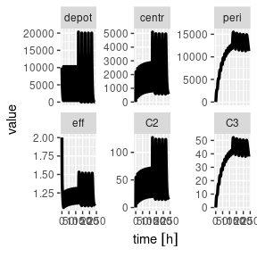

```r
plot(x)
```

## Modifying observation times for RxODE

Notice that the inital effect is now `2`.

You can also change the sampling times easily by this method by changing `t` or `time`. For example:

```r
x$t <- seq(0,5,length.out=20)
print(x)
```

```
#> ______________________________ Solved RxODE object _____________________________
#> -- Parameters ($params): -------------------------------------------------------
#>      V2      V3      KA      CL       Q     Kin    Kout    EC50
#>  40.200 297.000   0.294  18.600  10.500   1.000   1.000 200.000
#> -- Initial Conditions ($inits): ------------------------------------------------
#> depot centr  peri   eff
#>     0     0     0     2
#> -- First part of data (object): ------------------------------------------------
#> # A tibble: 20 x 7
#>        time    C2     C3  depot centr  peri   eff
#>         [h] <dbl>  <dbl>  <dbl> <dbl> <dbl> <dbl>
#> 1 0.0000000   0   0      10000     0    0    2
#> 2 0.2631579  16.8 0.0817  9255.  677.  24.3  1.79
#> 3 0.5263158  29.5 0.299   8566. 1187.  88.7  1.65
#> 4 0.7894737  38.9 0.615   7929. 1562. 183.   1.55
#> 5 1.0526316  45.5 1.00    7338. 1830. 298.   1.49
#> 6 1.3157895  50.1 1.44    6792. 2013. 427.   1.44
#> # ... with 14 more rows
```

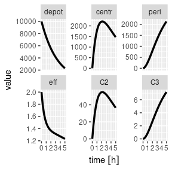

```r
plot(x)
```

## Modifying simulation parameters

You can also access or change parameters by the `$` operator. For example, accessing `KA` can be done by:

```r
x$KA
```

```
#> [1] 0.294
```

And you may change it by assigning it to a new value.

```r
x$KA <- 1;
print(x)
```

```
#> ______________________________ Solved RxODE object _____________________________
#> -- Parameters ($params): -------------------------------------------------------
#>    V2    V3    KA    CL     Q   Kin  Kout  EC50
#>  40.2 297.0   1.0  18.6  10.5   1.0   1.0 200.0
#> -- Initial Conditions ($inits): ------------------------------------------------
#> depot centr  peri   eff
#>     0     0     0     2
#> -- First part of data (object): ------------------------------------------------
#> # A tibble: 20 x 7
#>        time    C2    C3  depot centr   peri   eff
#>         [h] <dbl> <dbl>  <dbl> <dbl>  <dbl> <dbl>
#> 1 0.0000000   0   0     10000     0     0    2
#> 2 0.2631579  52.2 0.261  7686. 2098.   77.6  1.82
#> 3 0.5263158  83.3 0.900  5908. 3348.  267.   1.74
#> 4 0.7894737  99.8 1.75   4541. 4010.  519.   1.69
#> 5 1.0526316 106.  2.69   3490. 4273.  800.   1.67
#> 6 1.3157895 106.  3.66   2683. 4272. 1086.   1.64
#> # ... with 14 more rows
```

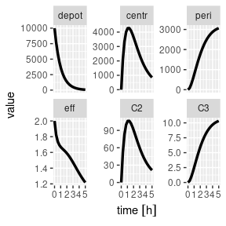

```r
plot(x)
```

You can access/change all the parametrs, initilizations or events with the `$params`, `$inits`, `$events` accessor syntax, similar to what is used above.

This syntax makes it easy to update and explore the effect of various parameters on the solved object.